# Metabolic_Zebra

Thomas Z

14 juillet 2019

Équipe sur le papier: Thomas Z., Lyette R., Audrey L.P., François V., Pierrot L.

Analyses des données de BMR sur les diamants exposés durant leur croissance à deux traitements: - 1) Imidacloprid / ctrl - 2) restriction alimentaire / Ad libitum

Les mesures ont été réalisées sur des oiseaux de deux ans.

Nous avons donc des données de QMR et BMR. L’idée est simple, puisqu’il s’agit de comparer le BMR suivant les traitements mais également les compositions corporelles. Je présente ici une première analyse, essentiellement composée de graphiques exploratoires et de quelques tests pour valider les tendances.

IMPORTANT Comme pour le papier 1, je déroule, dans un premier temps l’analyse avec l’ensemble du dataset puis décompose le jeu entre la période A et B (différences de concentrations en IMI)

## Aspect Général

### 1) Visualisation des données

```r
# Import des données
BMR_OK <- read.csv("~/Documents/Doctorat/Experimental/Zebra finch/BMR/BMR_OK_COMPLET.csv")
Masse_heure <- read.csv("~/Documents/Doctorat/Experimental/Zebra finch/BMR/Masse_heure.csv", dec= ",")

# merge des tables
BMR <- merge(BMR_OK, Masse_heure, by="COMBI_FINAL", all=FALSE)


# Création d'un vecteur simple pour test d'analyse (comme Papier #1)
BMR$TRT <- paste(BMR$PEST, BMR$TREATMENT, sep="_")

# Min - Max
range(BMR$Mean_VO2watt_1)
```

```
## [1] 0.1325055 0.4652858
```

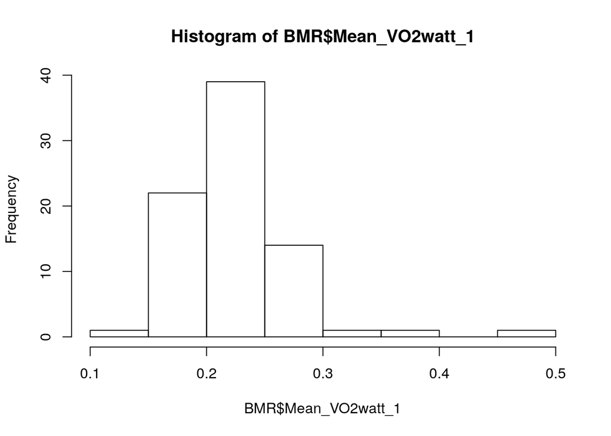

```r
# histogramme des données d'intérets
hist(BMR$Mean_VO2watt_1)
```

```r
shapiro.test(BMR$Mean_VO2watt_1)
```

```
##
##  Shapiro-Wilk normality test
##
## data:  BMR$Mean_VO2watt_1
## W = 0.88306, p-value = 2.842e-06
```

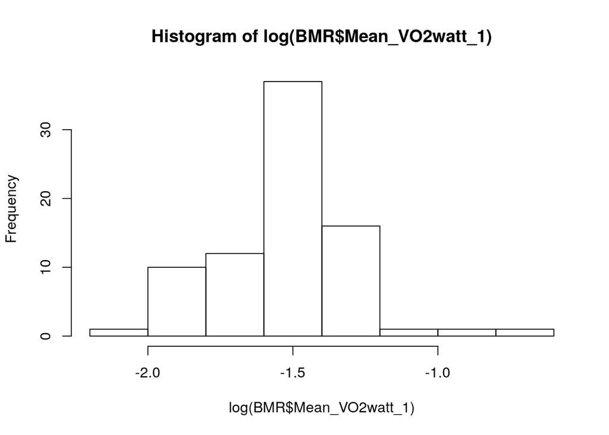

```r
# pas de normalité

# transformation log
hist(log(BMR$Mean_VO2watt_1))
```

```r
# Une transformation log me va
shapiro.test(log(BMR$Mean_VO2watt_1))
```

```
##
##  Shapiro-Wilk normality test
##
## data:  log(BMR$Mean_VO2watt_1)
## W = 0.95924, p-value = 0.01287
```

```r
# toujours de normalité si on suit shapiro.

# L'individu avec la valeur max de VO2watt
# Je ne suis pas pour le retirer.
#BMR <- subset(BMR, COMBI_FINAL != "Y65")
```

### 2) Répartion

- Adlib ctrl n= 17 (9 M + 8 F)
- Adlib imi n= 17 (7M 10F)
- Restriction imi n= 23 (12M 11F)
- Restriction ctrl n= 22 (12 M + 10 F)

### 3) Création du mass corrected BMR et du rapport de FAT sur LEAN

Le BMR (en Watt) est divisé par la masse. À des fins exploratoires, je créee aussi un ration Fat/Lean

```r
BMR$BMR_MassCor <- (BMR$Mean_VO2watt_1/BMR$masse.moyenne.entree.bmr)

BMR$BMR_LeanCor <- (BMR$Mean_VO2watt_1/BMR$prebmr.Moyenne_Lean)

BMR$Fat_LeanRatio <- BMR$prebmr.Moyenne_Fat/BMR$prebmr.Moyenne_Lean

# calcul SMI
Cor_SMI <- select(BMR, masse.moyenne.entree.bmr , TARSUS90, TB90)
# matrice de corrélation: sélection de la variable la + corrélée à la masse
cor(Cor_SMI, use = "complete.obs")
```

```
##                          masse.moyenne.entree.bmr  TARSUS90      TB90
## masse.moyenne.entree.bmr                1.0000000 0.3773733 0.1237264
## TARSUS90                                0.3773733 1.0000000 0.4495807
## TB90                                    0.1237264 0.4495807 1.0000000
```

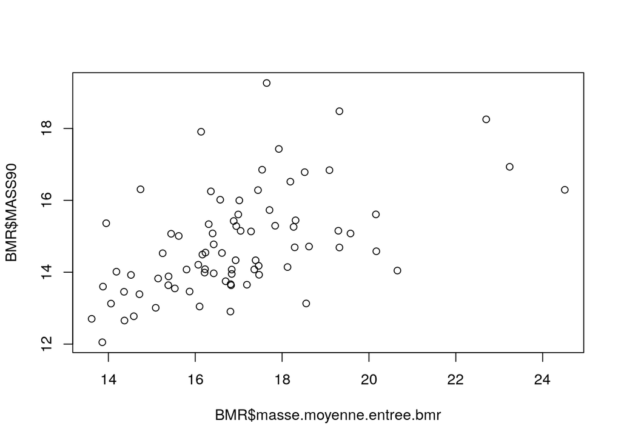

```r
# Sélection de TB pour le smi

plot(BMR$masse.moyenne.entree.bmr,BMR$MASS90)
```

```r
cor(BMR$masse.moyenne.entree.bmr,BMR$MASS90)
```

```
## [1] 0.5275099
```

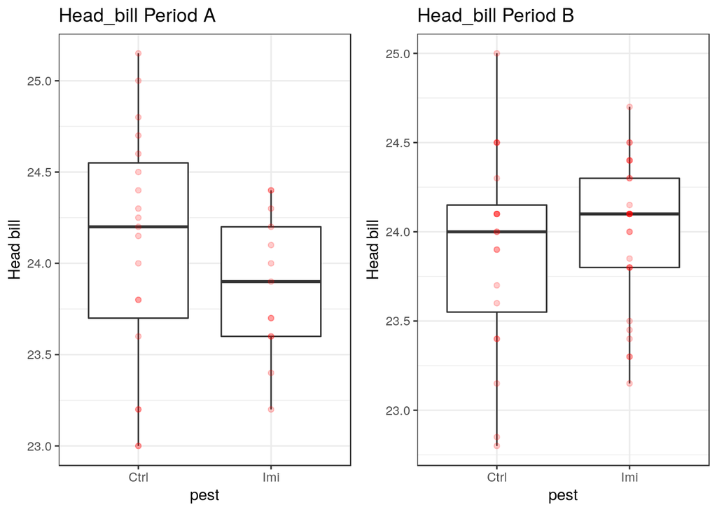

```r
p2 =cor.test(BMR$masse.moyenne.entree.bmr, BMR$TARSUS90, method = "pearson")
lm2<-lm(masse.moyenne.entree.bmr~TARSUS90,data=BMR)
c2=as.data.frame(lm2$coefficients)
bSMA2=c2[2,1]/p2$estimate
BMR$SMI=BMR$masse.moyenne.entree.bmr*(mean(BMR$TARSUS90)/BMR$TARSUS90)^bSMA2


# Comme les analyses seront probablement séparées par Periode, on scinde le dataset
BMR_A <- subset(BMR, GROUPE=="A")
BMR_B <- subset(BMR,GROUPE=="B")


# On début par quelques graphs de tailles structurelles des oiseaux en utilisant les TB et Tarsus au jour 90
p4A<- ggplot(BMR_A, aes(x=PEST, y = TB90 )) + geom_boxplot()+
  theme_bw()+
  geom_point(aes(x = PEST, y = TB90), col = "red", alpha = 0.2)+
  labs(title="Head_bill Period A",
        x ="pest", y = "Head bill")

p4B<- ggplot(BMR_B, aes(x=PEST, y = TB90 )) + geom_boxplot()+
  theme_bw()+
  geom_point(aes(x = PEST, y = TB90), col = "red", alpha = 0.2)+
  labs(title="Head_bill Period B",
        x ="pest", y = "Head bill")

grid.arrange(p4A, p4B,ncol=2)
```

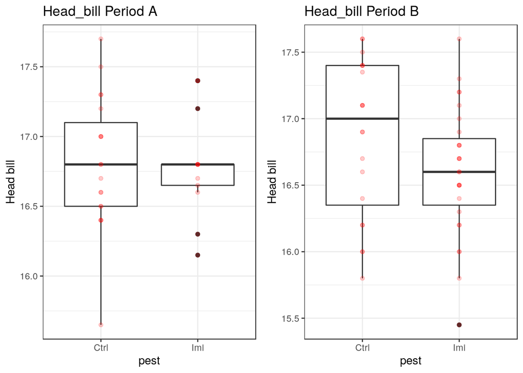

```r
# Tarsus

p4A<- ggplot(BMR_A, aes(x=PEST, y = TARSUS90 )) + geom_boxplot()+
  theme_bw()+
  geom_point(aes(x = PEST, y = TARSUS90), col = "red", alpha = 0.2)+
  labs(title="Head_bill Period A",
        x ="pest", y = "Head bill")

p4B<- ggplot(BMR_B, aes(x=PEST, y = TARSUS90 )) + geom_boxplot()+
  theme_bw()+
  geom_point(aes(x = PEST, y = TARSUS90), col = "red", alpha = 0.2)+
  labs(title="Head_bill Period B",
        x ="pest", y = "Head bill")

grid.arrange(p4A, p4B,ncol=2)
```

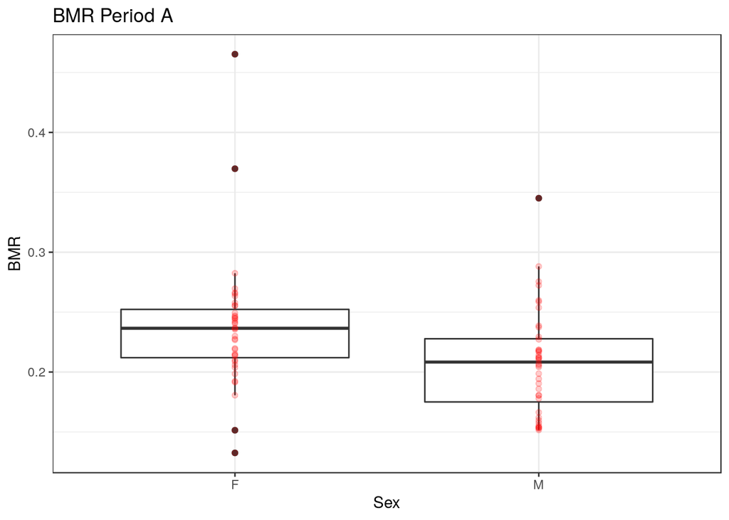

```r
###

p4<- ggplot(BMR, aes(x=SEX, y = Mean_VO2watt_1 )) + geom_boxplot()+
  theme_bw()+
  geom_point(aes(x = SEX, y = Mean_VO2watt_1), col = "red", alpha = 0.2)+
  labs(title="BMR Period A",
        x ="Sex", y = "BMR")

p4
```

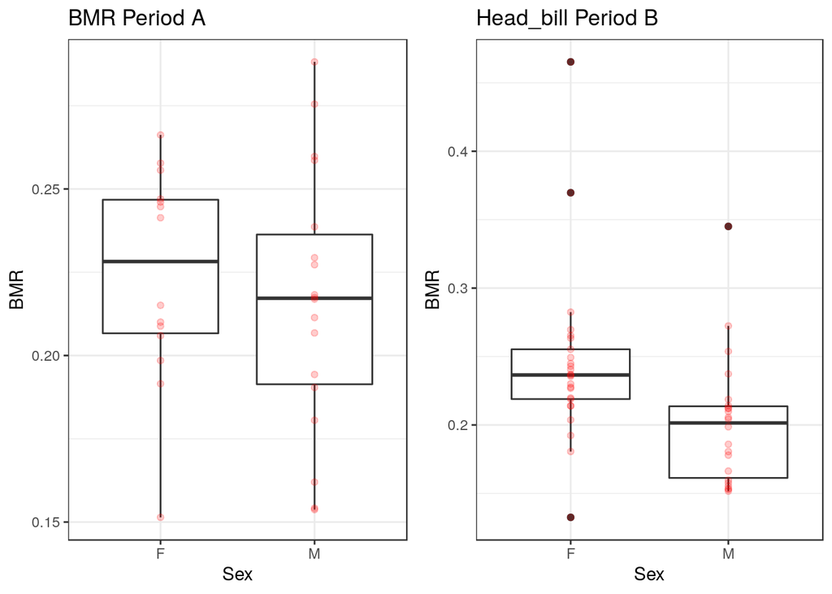

```r
p4A<- ggplot(BMR_A, aes(x=SEX, y = Mean_VO2watt_1 )) + geom_boxplot()+
  theme_bw()+
  geom_point(aes(x = SEX, y = Mean_VO2watt_1), col = "red", alpha = 0.2)+
  labs(title="BMR Period A",
        x ="Sex", y = "BMR")

p4B<- ggplot(BMR_B, aes(x=SEX, y = Mean_VO2watt_1 )) + geom_boxplot()+
  theme_bw()+
  geom_point(aes(x = SEX, y = Mean_VO2watt_1), col = "red", alpha = 0.2)+
  labs(title="Head_bill Period B",
        x ="Sex", y = "BMR")

grid.arrange(p4A, p4B,ncol=2)
```

```r
# ANOVA de l'effet sex
# ANOVA
res.aov <- aov(Mean_VO2watt_1 ~ SEX, data = BMR)
TukeyHSD(res.aov)
```

```
##   Tukey multiple comparisons of means
##     95% family-wise confidence level
##
## Fit: aov(formula = Mean_VO2watt_1 ~ SEX, data = BMR)
##
## $SEX
##            diff         lwr          upr  p adj
## M-F -0.02967916 -0.05159484 -0.007763484 0.0086
```

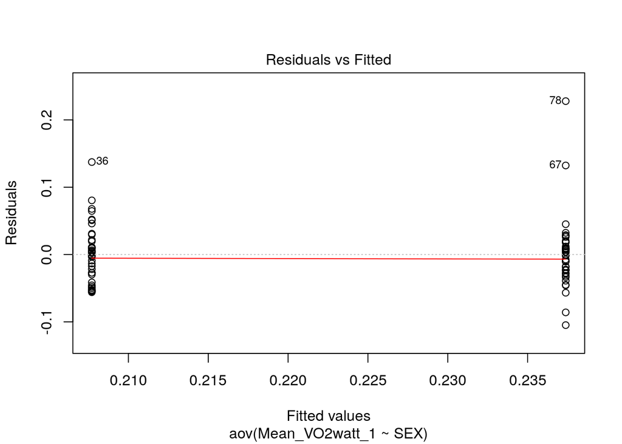

```r
# Summary of the analysis
plot(res.aov, 1)
```

```r
leveneTest(Mean_VO2watt_1 ~ TRT, data = BMR_A)
```

```
## Levene's Test for Homogeneity of Variance (center = median)
##       Df F value Pr(>F)
## group  3  0.5613  0.645
##       28
```

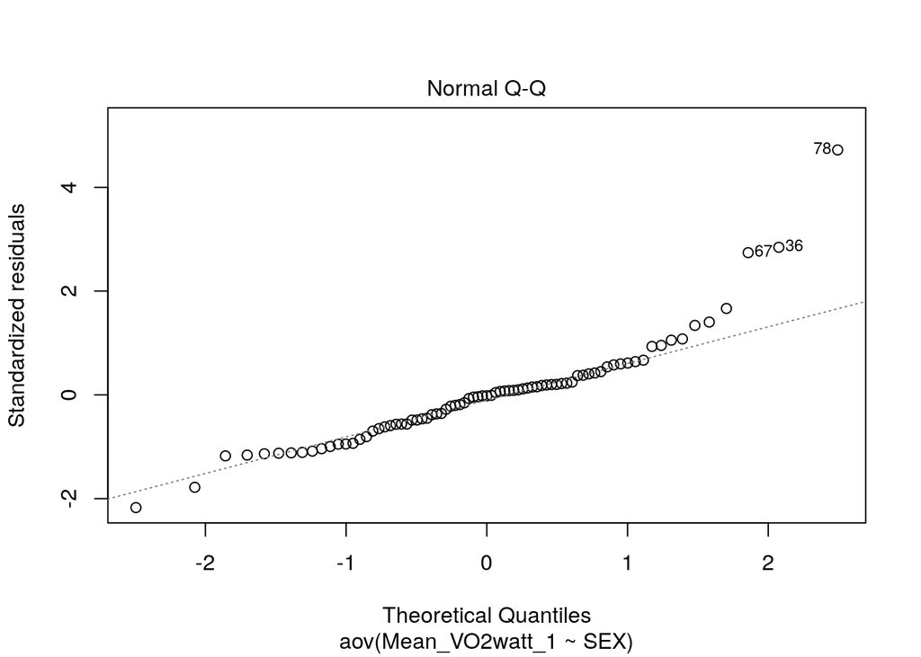

```r
plot(res.aov, 2)
```

### Calcul d’un SMI 2 ans

Pour se faire, j’utilise la valeur morpho mesuré au jour 90, la plus corrélée. Ces variables morpho sont jugés constante à cette age.

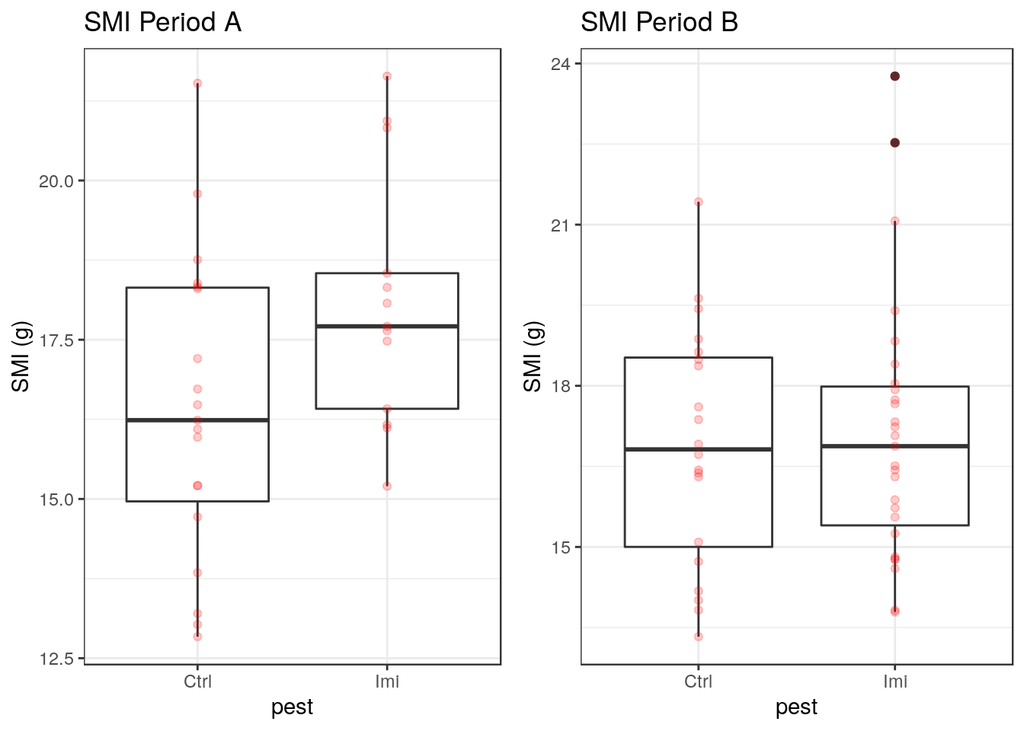

```r
# SMI


p4A<- ggplot(BMR_A, aes(x=PEST, y = SMI )) + geom_boxplot()+
  theme_bw()+
  geom_point(aes(x = PEST, y = SMI), col = "red", alpha = 0.2)+
  labs(title="SMI Period A",
        x ="pest", y = "SMI (g)")

p4B<- ggplot(BMR_B, aes(x=PEST, y = SMI)) + geom_boxplot()+
  theme_bw()+
  geom_point(aes(x = PEST, y = SMI), col = "red", alpha = 0.2)+
  labs(title="SMI Period B",
        x ="pest", y = "SMI (g)")

grid.arrange(p4A, p4B,ncol=2)
```

```r
# ANOVA SMI ~ TRT

# ANOVA
res.aov <- aov(SMI ~ TRT, data = BMR_A)
TukeyHSD(res.aov)
```

```
##   Tukey multiple comparisons of means
##     95% family-wise confidence level
##
## Fit: aov(formula = SMI ~ TRT, data = BMR_A)
##
## $TRT
##                              diff       lwr      upr     p adj
## Ctrl_Res-Ctrl_Ad lib    0.9335715 -1.961582 3.828725 0.8149280
## Imi_Ad lib-Ctrl_Ad lib  2.3895858 -1.162454 5.941626 0.2779606
## Imi_Res-Ctrl_Ad lib     2.0959084 -1.019437 5.211253 0.2779207
## Imi_Ad lib-Ctrl_Res     1.4560143 -1.904570 4.816599 0.6423539
## Imi_Res-Ctrl_Res        1.1623369 -1.732817 4.057490 0.6947446
## Imi_Res-Imi_Ad lib     -0.2936774 -3.845717 3.258362 0.9958474
```

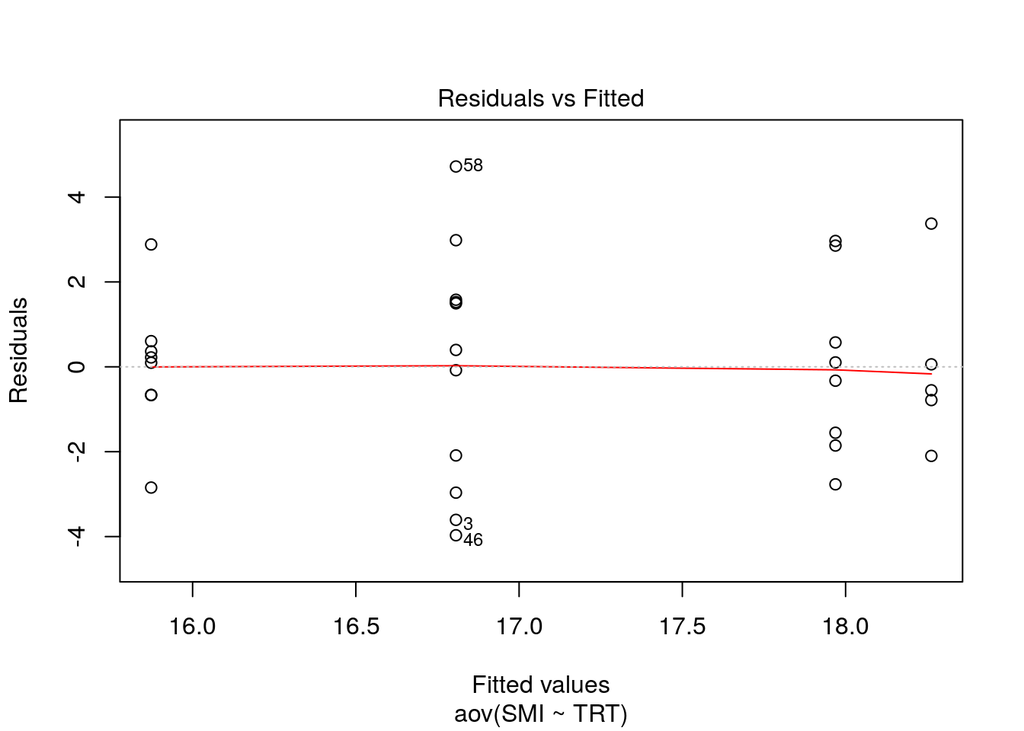

```r
# Summary of the analysis
plot(res.aov, 1)
```

```r
leveneTest(Mean_VO2watt_1 ~ TRT, data = BMR_A)
```

```
## Levene's Test for Homogeneity of Variance (center = median)
##       Df F value Pr(>F)
## group  3  0.5613  0.645
##       28
```

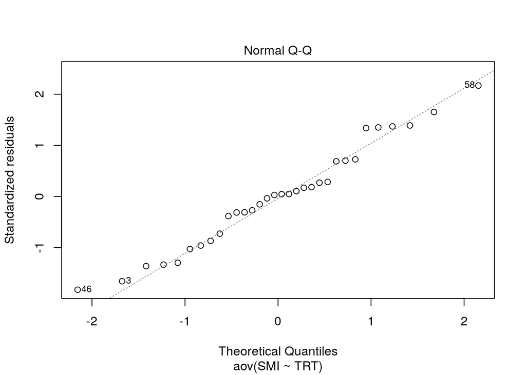

```r
plot(res.aov, 2)
```

## Graphiques exploratoires

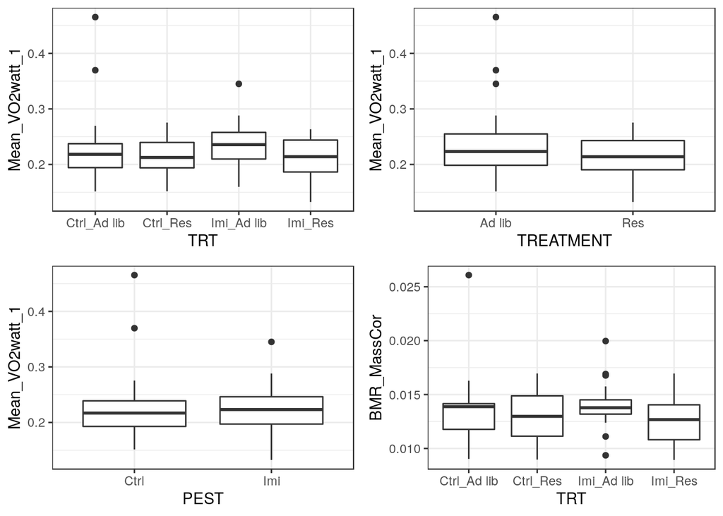

```r
par(mfrow=c(2,2))
p1 <- ggplot(BMR, aes(x=TRT, y = Mean_VO2watt_1)) + geom_boxplot()+
theme_bw()
p2 <- ggplot(BMR, aes(x=TREATMENT, y = Mean_VO2watt_1)) + geom_boxplot()+
theme_bw()
p3<- ggplot(BMR, aes(x=PEST, y = Mean_VO2watt_1)) + geom_boxplot()+
theme_bw()
p4<- ggplot(BMR, aes(x=TRT, y = BMR_MassCor)) + geom_boxplot()+
theme_bw()
grid.arrange(p1, p2, p3, p4, ncol = 2)
```

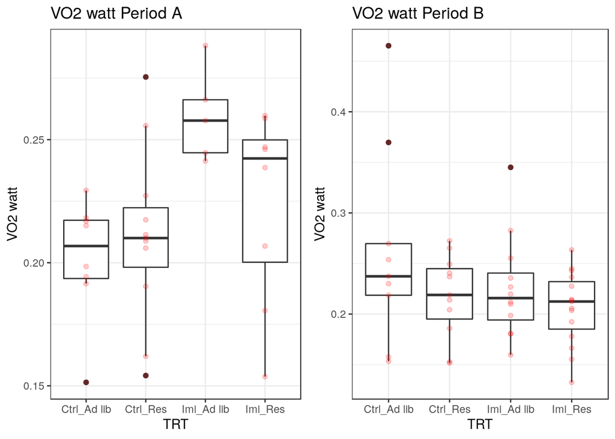

```r
p1A <- ggplot(BMR_A, aes(x=TRT, y = Mean_VO2watt_1)) + geom_boxplot() +
  theme_bw()+
  geom_point(aes(x = TRT, y = Mean_VO2watt_1), col = "red", alpha = 0.2)+
labs(title="VO2 watt Period A",
        x ="TRT", y = "VO2 watt")
p1B <- ggplot(BMR_B, aes(x=TRT, y = Mean_VO2watt_1)) + geom_boxplot()+
  theme_bw()+
  geom_point(aes(x = TRT, y = Mean_VO2watt_1), col = "red", alpha = 0.2)+
labs(title="VO2 watt Period B",
        x ="TRT", y = "VO2 watt")
grid.arrange(p1A, p1B, ncol = 2)
```

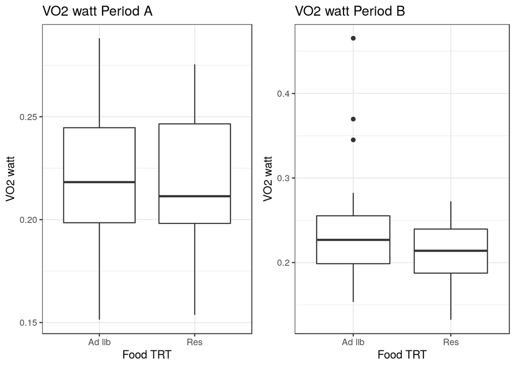

```r
p2A <- ggplot(BMR_A, aes(x=TREATMENT, y = Mean_VO2watt_1)) + geom_boxplot()+
  theme_bw()+
labs(title="VO2 watt Period A",
        x ="Food TRT", y = "VO2 watt")
p2B <- ggplot(BMR_B, aes(x=TREATMENT, y = Mean_VO2watt_1)) + geom_boxplot()+
  theme_bw()+
  labs(title="VO2 watt Period B",
        x ="Food TRT", y = "VO2 watt")
grid.arrange(p2A, p2B, ncol = 2)
```

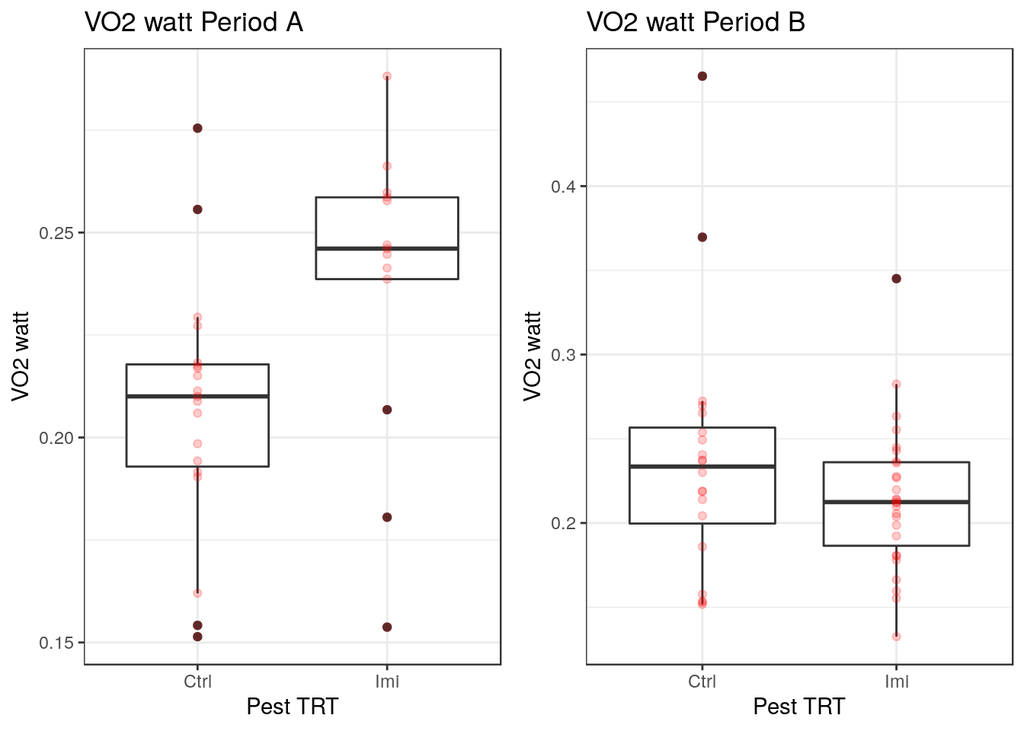

```r
p3A<- ggplot(BMR_A, aes(x=PEST, y = Mean_VO2watt_1)) + geom_boxplot()+
  theme_bw()+
  geom_point(aes(x = PEST, y = Mean_VO2watt_1), col = "red", alpha = 0.2)+
  labs(title="VO2 watt Period A",
        x ="Pest TRT", y = "VO2 watt")
p3B<- ggplot(BMR_B, aes(x=PEST, y = Mean_VO2watt_1)) + geom_boxplot()+
  theme_bw()+
  geom_point(aes(x = PEST, y = Mean_VO2watt_1), col = "red", alpha = 0.2)+
  labs(title="VO2 watt Period B",
        x ="Pest TRT", y = "VO2 watt")
grid.arrange(p3A, p3B, ncol = 2)
```

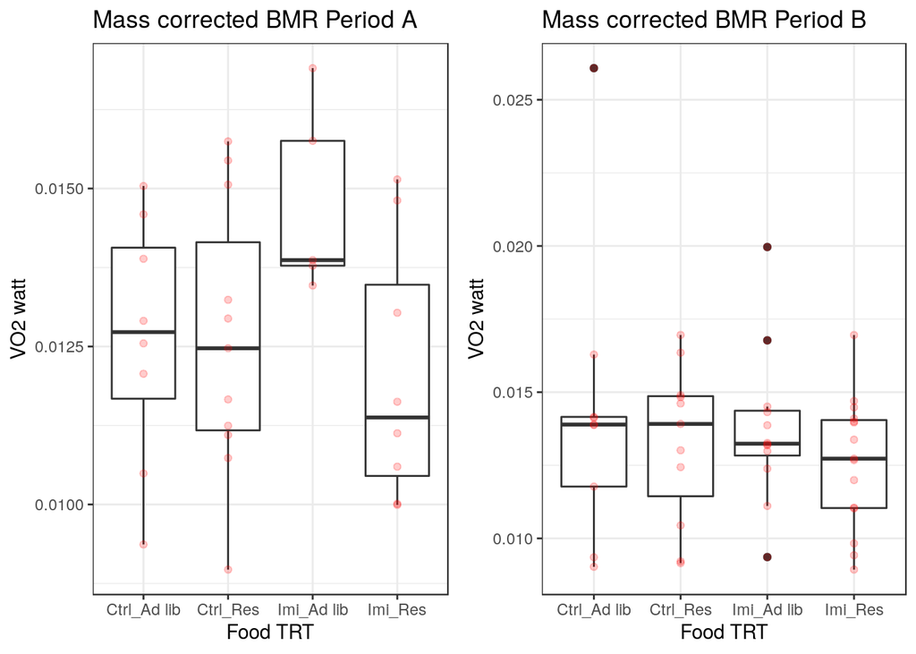

```r
p4A<- ggplot(BMR_A, aes(x=TRT, y = BMR_MassCor)) + geom_boxplot()+
  theme_bw()+
  geom_point(aes(x = TRT, y = BMR_MassCor), col = "red", alpha = 0.2)+
  labs(title="Mass corrected BMR Period A",
        x ="Food TRT", y = "VO2 watt")

  p4B<- ggplot(BMR_B, aes(x=TRT, y = BMR_MassCor)) + geom_boxplot()+
  theme_bw()+
   geom_point(aes(x = TRT, y = BMR_MassCor), col = "red", alpha = 0.2)+
    labs(title="Mass corrected BMR Period B",
        x ="Food TRT", y = "VO2 watt")
grid.arrange(p4A, p4B, ncol = 2)
```

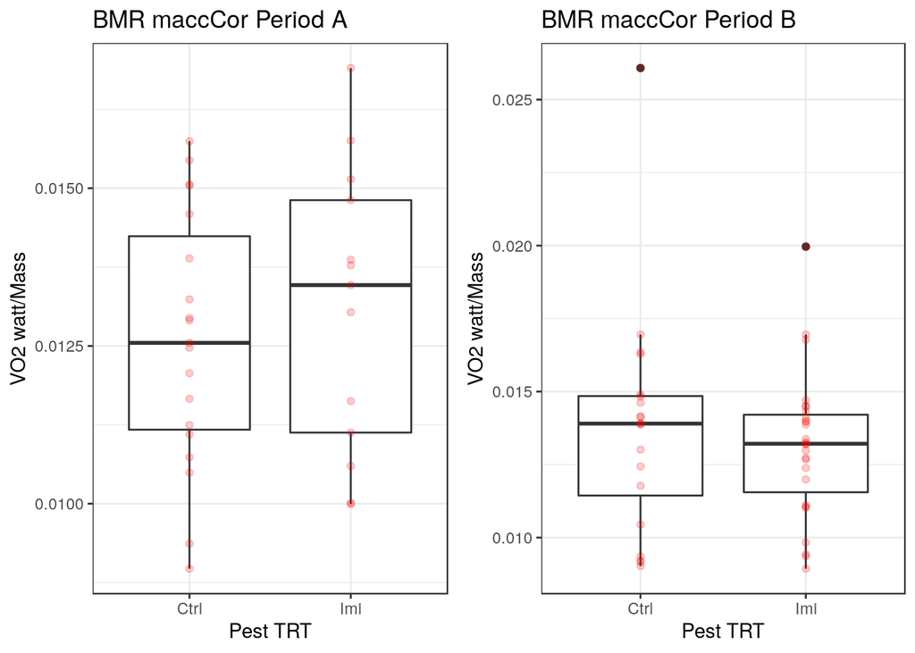

```r
p3A<- ggplot(BMR_A, aes(x=PEST, y = BMR_MassCor)) + geom_boxplot()+
  theme_bw()+
  geom_point(aes(x = PEST, y = BMR_MassCor), col = "red", alpha = 0.2)+
  labs(title="BMR maccCor Period A",
        x ="Pest TRT", y = "VO2 watt/Mass")
p3B<- ggplot(BMR_B, aes(x=PEST, y = BMR_MassCor)) + geom_boxplot()+
  theme_bw()+
  geom_point(aes(x = PEST, y = BMR_MassCor), col = "red", alpha = 0.2)+
  labs(title="BMR maccCor Period B",
        x ="Pest TRT", y = "VO2 watt/Mass")
grid.arrange(p3A, p3B, ncol = 2)
```

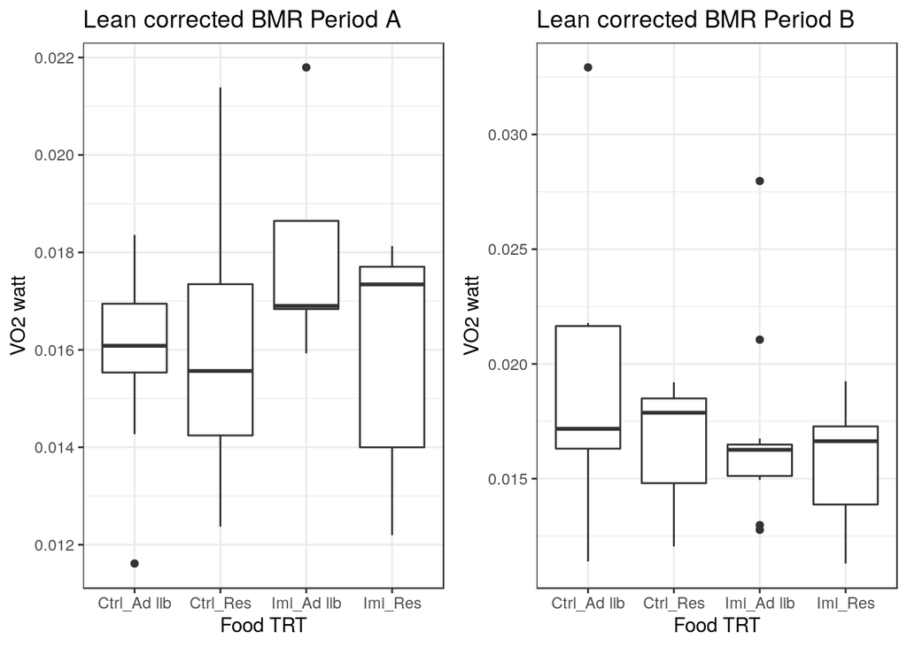

```r
p5A<- ggplot(BMR_A, aes(x=TRT, y = BMR_LeanCor)) + geom_boxplot()+
  theme_bw()+
  labs(title="Lean corrected BMR Period A",
        x ="Food TRT", y = "VO2 watt")
p5B<- ggplot(BMR_B, aes(x=TRT, y = BMR_LeanCor)) + geom_boxplot()+
  theme_bw()+
    labs(title="Lean corrected BMR Period B",
        x ="Food TRT", y = "VO2 watt")
grid.arrange(p5A, p5B, ncol = 2)
```

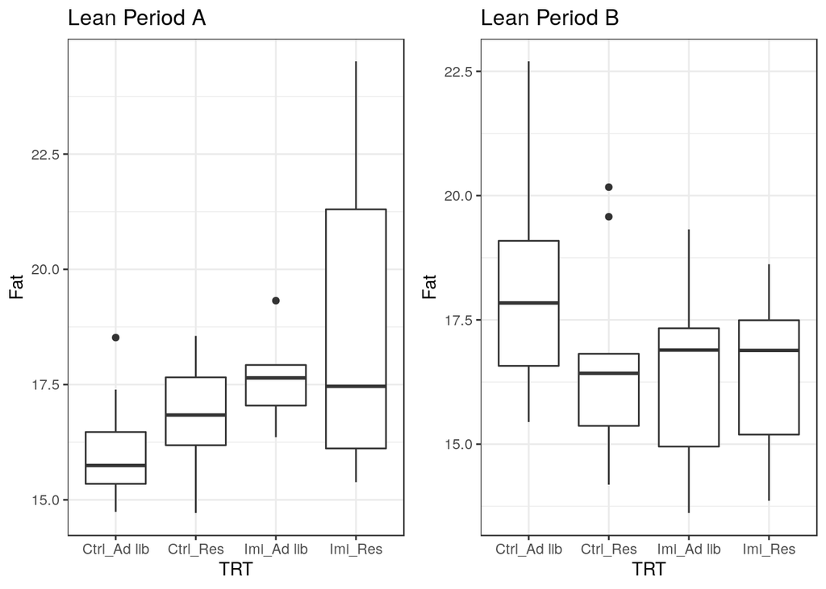

```r
p1A <- ggplot(BMR_A, aes(x=TRT, y = masse.moyenne.entree.bmr)) + geom_boxplot() +
  theme_bw()+
labs(title="Lean Period A",
        x ="TRT", y = "Fat")
p1B <- ggplot(BMR_B, aes(x=TRT, y = masse.moyenne.entree.bmr)) + geom_boxplot()+
  theme_bw()+
labs(title="Lean Period B",
        x ="TRT", y = "Fat")
grid.arrange(p1A, p1B, ncol = 2)
```

### Lean avec tout le jeu de données

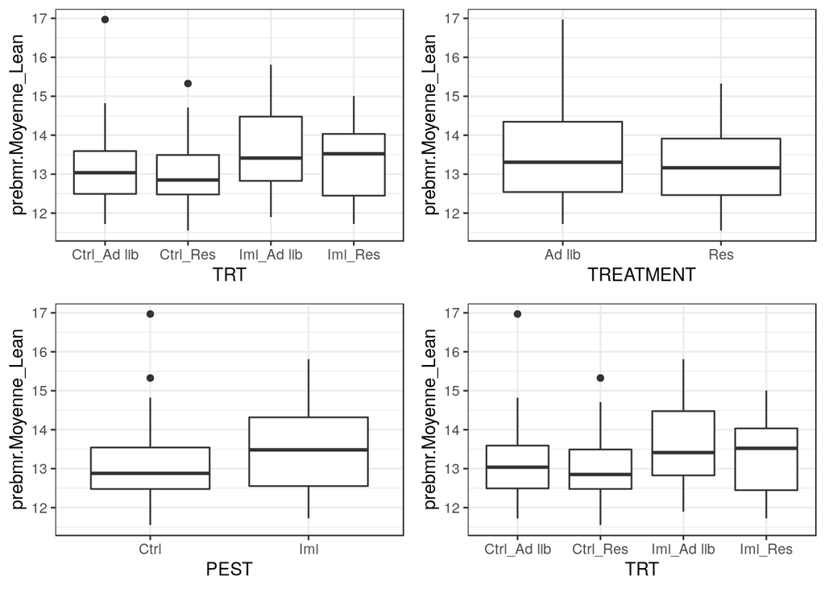

```r
par(mfrow=c(2,2))
p1 <- ggplot(BMR, aes(x=TRT, y = prebmr.Moyenne_Lean)) + geom_boxplot()+
  theme_bw()
p2 <- ggplot(BMR, aes(x=TREATMENT, y = prebmr.Moyenne_Lean)) + geom_boxplot()+
  theme_bw()
p3<- ggplot(BMR, aes(x=PEST, y = prebmr.Moyenne_Lean)) + geom_boxplot()+
  theme_bw()
p4<- ggplot(BMR, aes(x=TRT, y = prebmr.Moyenne_Lean)) + geom_boxplot()+
theme_bw()
grid.arrange(p1, p2, p3, p4, ncol = 2)
```

### Fat avec tout le jeu de données

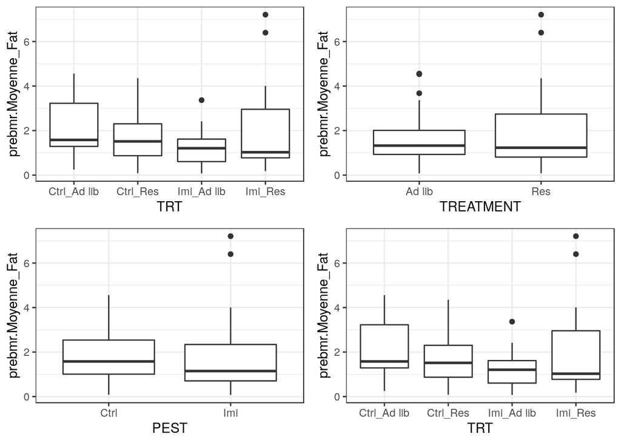

```r
par(mfrow=c(2,2))
p1 <- ggplot(BMR, aes(x=TRT, y = prebmr.Moyenne_Fat)) + geom_boxplot()+
  theme_bw()
p2 <- ggplot(BMR, aes(x=TREATMENT, y = prebmr.Moyenne_Fat)) + geom_boxplot()+
  theme_bw()
p3<- ggplot(BMR, aes(x=PEST, y = prebmr.Moyenne_Fat)) + geom_boxplot()+
  theme_bw()
p4<- ggplot(BMR, aes(x=TRT, y = prebmr.Moyenne_Fat)) + geom_boxplot()+
  theme_bw()
grid.arrange(p1, p2, p3, p4, ncol = 2)
```

### Lean entre la période A et B

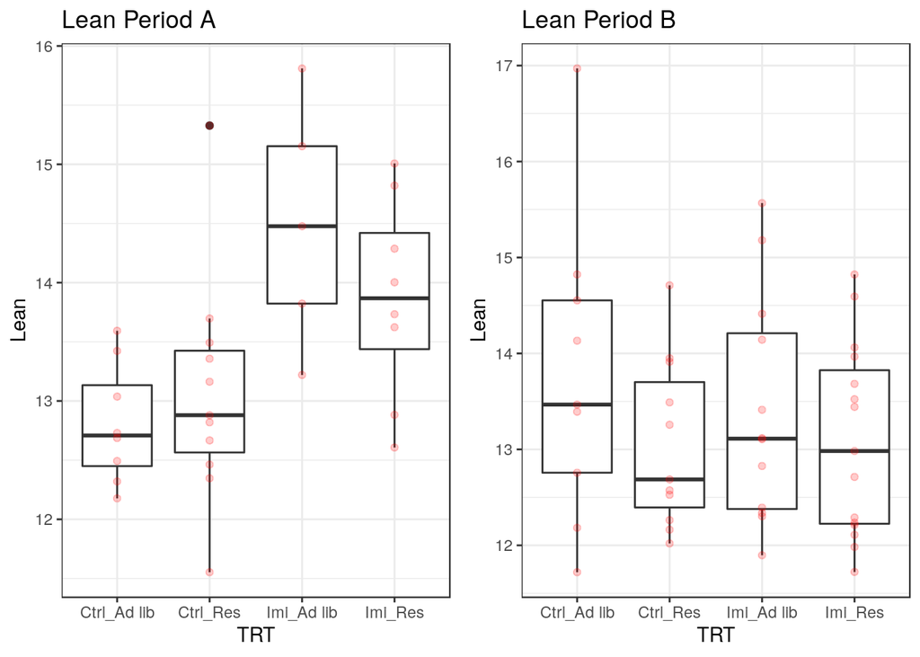

```r
p1A <- ggplot(BMR_A, aes(x=TRT, y = prebmr.Moyenne_Lean)) + geom_boxplot()+
  theme_bw()+
  geom_point(aes(x = TRT, y = prebmr.Moyenne_Lean), col = "red", alpha = 0.2)+
labs(title="Lean Period A",
        x ="TRT", y = "Lean")

p1B <- ggplot(BMR_B, aes(x=TRT, y = prebmr.Moyenne_Lean)) + geom_boxplot()+
  theme_bw()+
  geom_point(aes(x = TRT, y = prebmr.Moyenne_Lean), col = "red", alpha = 0.2)+
labs(title="Lean Period B",
        x ="TRT", y = "Lean")
grid.arrange(p1A, p1B, ncol = 2)
```

### Fat entre la période A et B entre tous les traitements

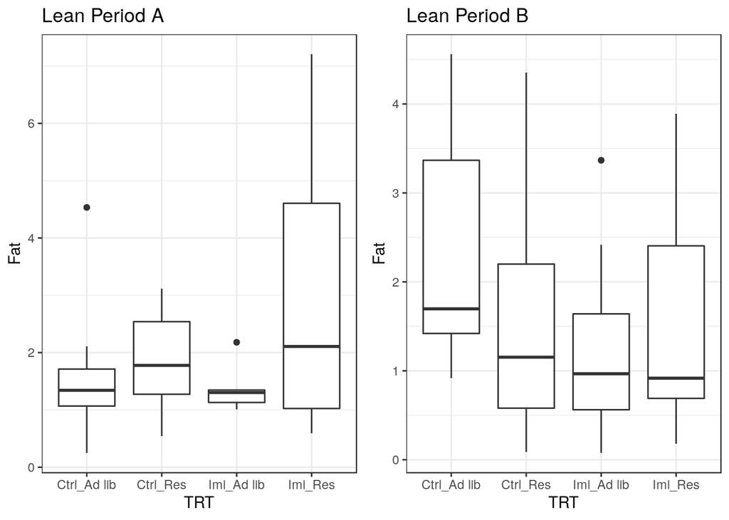

```r
p1A <- ggplot(BMR_A, aes(x=TRT, y = prebmr.Moyenne_Fat)) + geom_boxplot() +
  theme_bw()+
labs(title="Lean Period A",
        x ="TRT", y = "Fat")
p1B <- ggplot(BMR_B, aes(x=TRT, y = prebmr.Moyenne_Fat)) + geom_boxplot()+
  theme_bw()+
labs(title="Lean Period B",
        x ="TRT", y = "Fat")
grid.arrange(p1A, p1B, ncol = 2)
```

## Lean Period A et B suivant le traitement Food

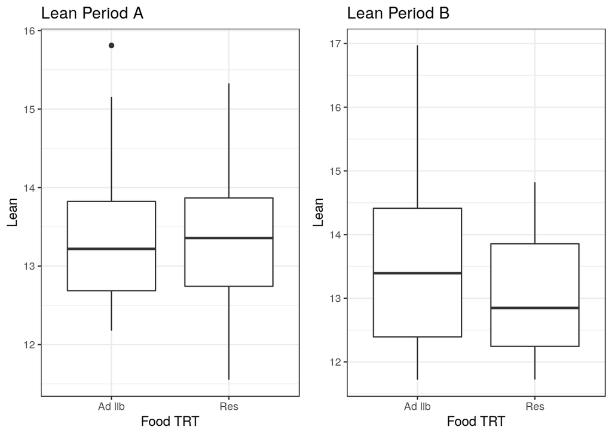

```r
p2A <- ggplot(BMR_A, aes(x=TREATMENT, y = prebmr.Moyenne_Lean)) + geom_boxplot()+
  theme_bw()+
labs(title="Lean Period A",
        x ="Food TRT", y = "Lean")
p2B <- ggplot(BMR_B, aes(x=TREATMENT, y = prebmr.Moyenne_Lean)) + geom_boxplot()+
  theme_bw()+
  labs(title="Lean Period B",
        x ="Food TRT", y = "Lean")
grid.arrange(p2A, p2B, ncol = 2)
```

## Fat entre A et B et suivant le traitement Food

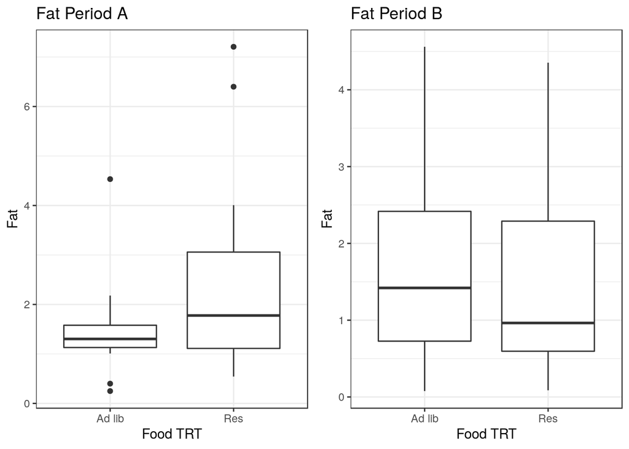

```r
p2A <- ggplot(BMR_A, aes(x=TREATMENT, y = prebmr.Moyenne_Fat)) + geom_boxplot()+
  theme_bw()+
labs(title="Fat Period A",
        x ="Food TRT", y = "Fat")
p2B <- ggplot(BMR_B, aes(x=TREATMENT, y = prebmr.Moyenne_Fat)) + geom_boxplot()+
  theme_bw()+
  labs(title="Fat Period B",
        x ="Food TRT", y = "Fat")
grid.arrange(p2A, p2B, ncol = 2)
```

### Lean entre A et B suivant le pesticide

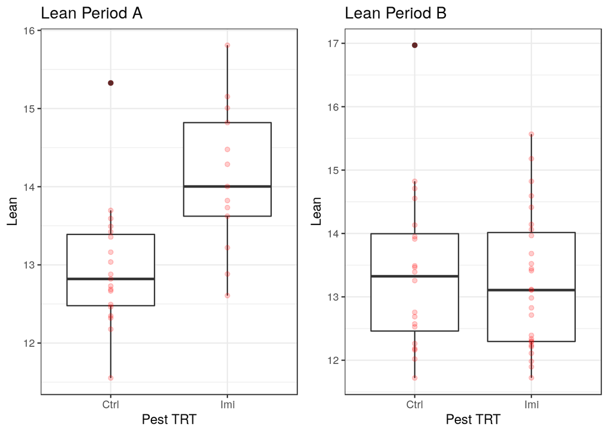

```r
p3A<- ggplot(BMR_A, aes(x=PEST, y =  prebmr.Moyenne_Lean)) + geom_boxplot()+
  theme_bw()+
  geom_point(aes(x = PEST, y = prebmr.Moyenne_Lean), col = "red", alpha = 0.2)+
  labs(title="Lean Period A",
        x ="Pest TRT", y = "Lean")
p3B<- ggplot(BMR_B, aes(x=PEST, y = prebmr.Moyenne_Lean)) + geom_boxplot()+
  theme_bw()+
  geom_point(aes(x = PEST, y = prebmr.Moyenne_Lean), col = "red", alpha = 0.2)+
  labs(title="Lean Period B",
        x ="Pest TRT", y = "Lean")
grid.arrange(p3A, p3B, ncol = 2)
```

### Fat entre A et B suivant le Pest

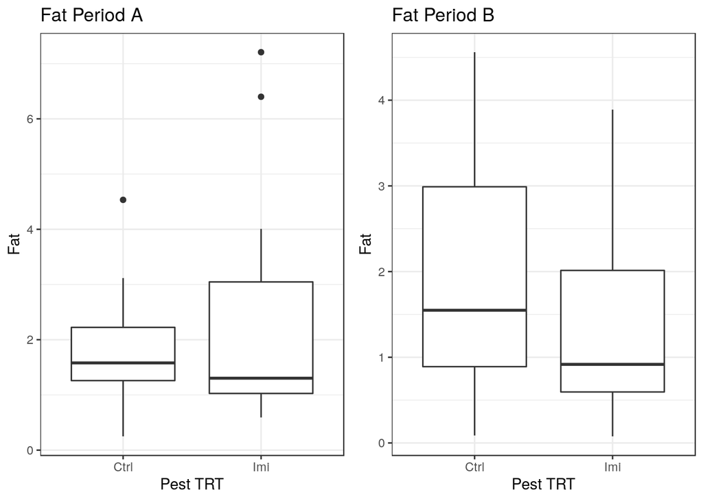

```r
p3A<- ggplot(BMR_A, aes(x=PEST, y =  prebmr.Moyenne_Fat)) + geom_boxplot()+
  theme_bw()+
  labs(title="Fat Period A",
        x ="Pest TRT", y = "Fat")
p3B<- ggplot(BMR_B, aes(x=PEST, y = prebmr.Moyenne_Fat)) + geom_boxplot()+
  theme_bw()+
  labs(title="Fat Period B",
        x ="Pest TRT", y = "Fat")
grid.arrange(p3A, p3B, ncol = 2)
```

## regression BMR/ Lean et Fat

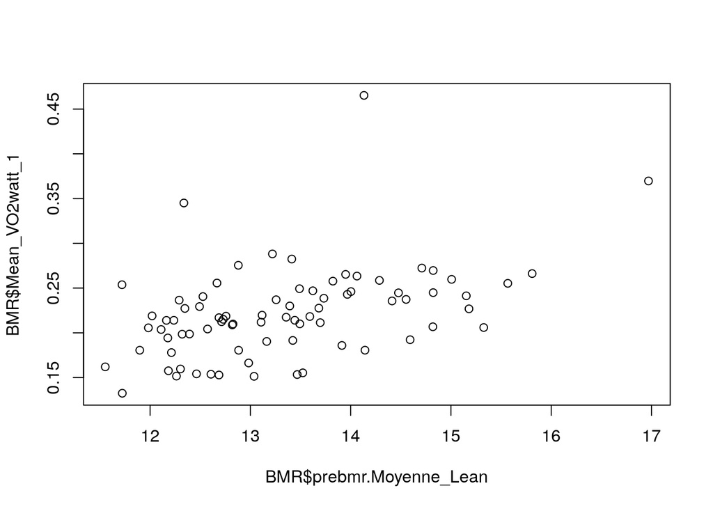

```r
plot(BMR$Mean_VO2watt_1 ~ BMR$prebmr.Moyenne_Lean)
```

```r
lm1 <- lm(BMR$Mean_VO2watt_1 ~ BMR$prebmr.Moyenne_Lean)
summary(lm1)
```

```
##
## Call:
## lm(formula = BMR$Mean_VO2watt_1 ~ BMR$prebmr.Moyenne_Lean)
##
## Residuals:
##       Min        1Q    Median        3Q       Max
## -0.071496 -0.025488 -0.001908  0.016477  0.226425
##
## Coefficients:
##                          Estimate Std. Error t value Pr(>|t|)
## (Intercept)             -0.057147   0.063372  -0.902     0.37
## BMR$prebmr.Moyenne_Lean  0.020944   0.004733   4.425 3.13e-05 ***
## ---
## Signif. codes:  0 '***' 0.001 '**' 0.01 '*' 0.05 '.' 0.1 ' ' 1
##
## Residual standard error: 0.04568 on 77 degrees of freedom
## Multiple R-squared:  0.2028, Adjusted R-squared:  0.1924
## F-statistic: 19.58 on 1 and 77 DF,  p-value: 3.131e-05
```

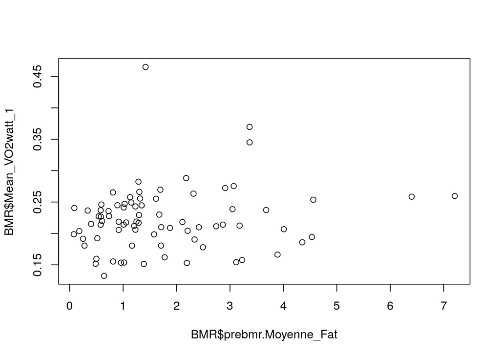

```r
plot(BMR$Mean_VO2watt_1 ~ BMR$prebmr.Moyenne_Fat)
```

```r
lm1 <- lm(BMR$Mean_VO2watt_1 ~ BMR$prebmr.Moyenne_Fat)
summary(lm1)
```

```
##
## Call:
## lm(formula = BMR$Mean_VO2watt_1 ~ BMR$prebmr.Moyenne_Fat)
##
## Residuals:
##       Min        1Q    Median        3Q       Max
## -0.083777 -0.025490 -0.001078  0.024048  0.244801
##
## Coefficients:
##                        Estimate Std. Error t value Pr(>|t|)
## (Intercept)            0.212805   0.009235  23.042   <2e-16 ***
## BMR$prebmr.Moyenne_Fat 0.005408   0.004116   1.314    0.193
## ---
## Signif. codes:  0 '***' 0.001 '**' 0.01 '*' 0.05 '.' 0.1 ' ' 1
##
## Residual standard error: 0.0506 on 77 degrees of freedom
## Multiple R-squared:  0.02193,    Adjusted R-squared:  0.00923
## F-statistic: 1.727 on 1 and 77 DF,  p-value: 0.1927
```

## Inspection statistique du BMR

```r
# ANOVA
res.aov <- aov(Mean_VO2watt_1 ~ TRT+SEX, data = BMR_A)
TukeyHSD(res.aov)
```

```
##   Tukey multiple comparisons of means
##     95% family-wise confidence level
##
## Fit: aov(formula = Mean_VO2watt_1 ~ TRT + SEX, data = BMR_A)
##
## $TRT
##                                diff           lwr        upr     p adj
## Ctrl_Res-Ctrl_Ad lib    0.008863278 -0.0327584445 0.05048500 0.9364181
## Imi_Ad lib-Ctrl_Ad lib  0.057715108  0.0066497626 0.10878045 0.0222965
## Imi_Res-Ctrl_Ad lib     0.021977638 -0.0228096327 0.06676491 0.5446960
## Imi_Ad lib-Ctrl_Res     0.048851829  0.0005389148 0.09716474 0.0467639
## Imi_Res-Ctrl_Res        0.013114359 -0.0285073638 0.05473608 0.8240458
## Imi_Res-Imi_Ad lib     -0.035737470 -0.0868028149 0.01532787 0.2455981
##
## $SEX
##              diff         lwr        upr     p adj
## M-F -0.0003756199 -0.02430851 0.02355727 0.9745471
```

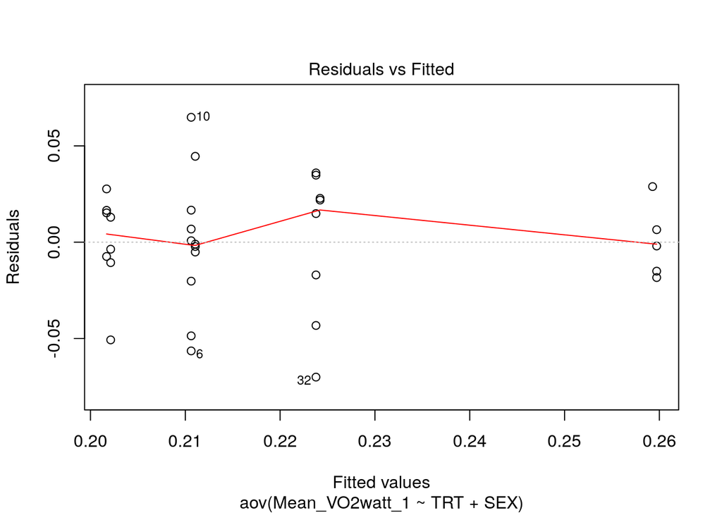

```r
# Summary of the analysis
plot(res.aov, 1)
```

```r
leveneTest(Mean_VO2watt_1 ~ TRT, data = BMR_A)
```

```
## Levene's Test for Homogeneity of Variance (center = median)
##       Df F value Pr(>F)
## group  3  0.5613  0.645
##       28
```

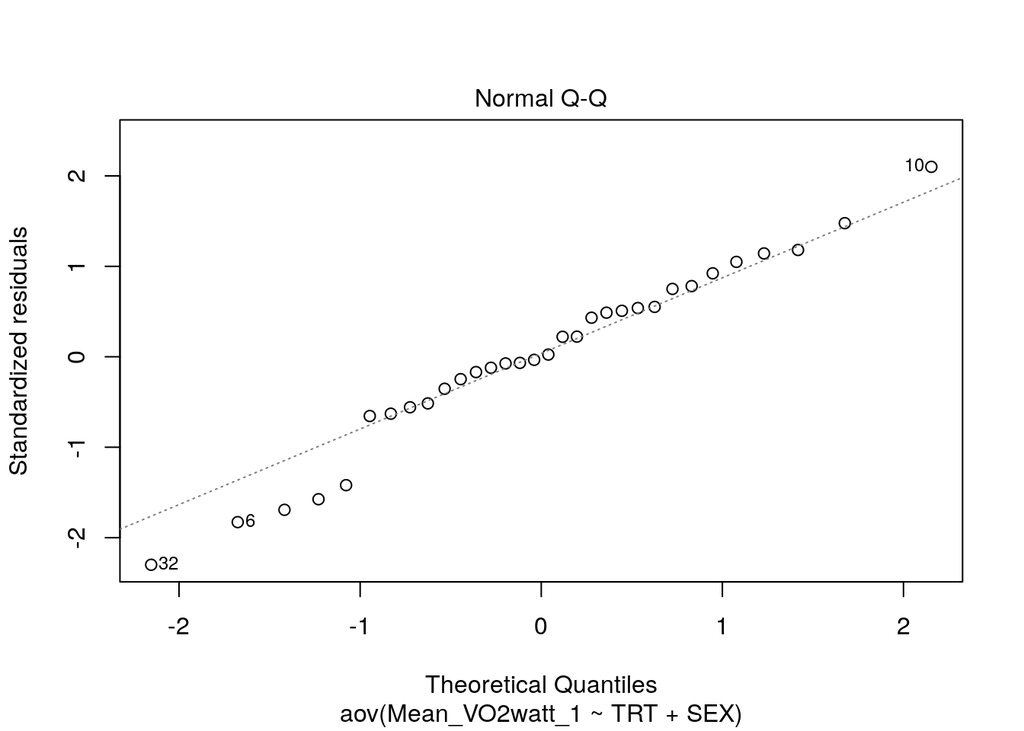

```r
plot(res.aov, 2)
```

```r
library(AICcmodavg)
options(na.action = "na.fail")
mp1 <- lmer(Mean_VO2watt_1~ PEST*TREATMENT + SEX + (1|PAIRS), data = BMR, REML = F)
summary(mp1)
```

```
## Linear mixed model fit by maximum likelihood . t-tests use
##   Satterthwaite's method [lmerModLmerTest]
## Formula: Mean_VO2watt_1 ~ PEST * TREATMENT + SEX + (1 | PAIRS)
##    Data: BMR
##
##      AIC      BIC   logLik deviance df.resid
##   -249.2   -232.7    131.6   -263.2       72
##
## Scaled residuals:
##     Min      1Q  Median      3Q     Max
## -1.7847 -0.5653 -0.0505  0.4849  3.2429
##
## Random effects:
##  Groups   Name        Variance  Std.Dev.
##  PAIRS    (Intercept) 0.0008929 0.02988
##  Residual             0.0014682 0.03832
## Number of obs: 79, groups:  PAIRS, 32
##
## Fixed effects:
##                       Estimate Std. Error        df t value Pr(>|t|)
## (Intercept)           0.248020   0.015716 31.322305  15.781   <2e-16 ***
## PESTImi              -0.006912   0.020591 29.164915  -0.336   0.7395
## TREATMENTRes         -0.019829   0.020324 24.971139  -0.976   0.3386
## SEXM                 -0.022657   0.009870 67.407119  -2.295   0.0248 *
## PESTImi:TREATMENTRes  0.004555   0.028249 26.127836   0.161   0.8731
## ---
## Signif. codes:  0 '***' 0.001 '**' 0.01 '*' 0.05 '.' 0.1 ' ' 1
##
## Correlation of Fixed Effects:
##             (Intr) PESTIm TREATM SEXM
## PESTImi     -0.701
## TREATMENTRs -0.695  0.530
## SEXM        -0.319  0.050  0.002
## PESTI:TREAT  0.513 -0.729 -0.720 -0.042
```

```r
mp1 <- lmer(Mean_VO2watt_1~ PEST+TREATMENT + SEX + (1|PAIRS), data = BMR, REML = F)
summary(mp1)
```

```
## Linear mixed model fit by maximum likelihood . t-tests use
##   Satterthwaite's method [lmerModLmerTest]
## Formula: Mean_VO2watt_1 ~ PEST + TREATMENT + SEX + (1 | PAIRS)
##    Data: BMR
##
##      AIC      BIC   logLik deviance df.resid
##   -251.2   -237.0    131.6   -263.2       73
##
## Scaled residuals:
##     Min      1Q  Median      3Q     Max
## -1.7716 -0.5644 -0.0418  0.4799  3.2600
##
## Random effects:
##  Groups   Name        Variance Std.Dev.
##  PAIRS    (Intercept) 0.000891 0.02985
##  Residual             0.001470 0.03834
## Number of obs: 79, groups:  PAIRS, 32
##
## Fixed effects:
##               Estimate Std. Error        df t value Pr(>|t|)
## (Intercept)   0.246725   0.013486 32.835065  18.295   <2e-16 ***
## PESTImi      -0.004488   0.014085 25.749359  -0.319   0.7526
## TREATMENTRes -0.017474   0.014108 26.217718  -1.239   0.2265
## SEXM         -0.022601   0.009865 67.418447  -2.291   0.0251 *
## ---
## Signif. codes:  0 '***' 0.001 '**' 0.01 '*' 0.05 '.' 0.1 ' ' 1
##
## Correlation of Fixed Effects:
##             (Intr) PESTIm TREATM
## PESTImi     -0.557
## TREATMENTRs -0.547  0.012
## SEXM        -0.347  0.028 -0.040
```

```r
options(na.action = "na.fail")
mp1 <- lmer(Mean_VO2watt_1~ TRT + SEX + (1|PAIRS), data = BMR_A, REML = F)
summary(mp1)
```

```
## Linear mixed model fit by maximum likelihood . t-tests use
##   Satterthwaite's method [lmerModLmerTest]
## Formula: Mean_VO2watt_1 ~ TRT + SEX + (1 | PAIRS)
##    Data: BMR_A
##
##      AIC      BIC   logLik deviance df.resid
##   -119.5   -109.2     66.7   -133.5       25
##
## Scaled residuals:
##      Min       1Q   Median       3Q      Max
## -2.32954 -0.51647 -0.00439  0.59679  2.15666
##
## Random effects:
##  Groups   Name        Variance Std.Dev.
##  PAIRS    (Intercept) 0.000000 0.00000
##  Residual             0.000904 0.03007
## Number of obs: 32, groups:  PAIRS, 14
##
## Fixed effects:
##                 Estimate Std. Error         df t value Pr(>|t|)
## (Intercept)    0.2021301  0.0120837 32.0000000  16.728  < 2e-16 ***
## TRTCtrl_Res    0.0089222  0.0140584 32.0000000   0.635  0.53017
## TRTImi_Ad lib  0.0575855  0.0174839 32.0000000   3.294  0.00242 **
## TRTImi_Res     0.0220857  0.0153054 32.0000000   1.443  0.15874
## SEXM          -0.0004321  0.0114917 32.0000000  -0.038  0.97024
## ---
## Signif. codes:  0 '***' 0.001 '**' 0.01 '*' 0.05 '.' 0.1 ' ' 1
##
## Correlation of Fixed Effects:
##             (Intr) TRTC_R TRTI_l TRTI_R
## TRTCtrl_Res -0.612
## TRTImi_Adlb -0.629  0.438
## TRTImi_Res  -0.522  0.546  0.385
## SEXM        -0.476 -0.111  0.197 -0.188
```

```r
mp1 <- lmer(Mean_VO2watt_1~ TRT + (1|PAIRS), data = BMR_A, REML = F)
summary(mp1)
```

```
## Linear mixed model fit by maximum likelihood . t-tests use
##   Satterthwaite's method [lmerModLmerTest]
## Formula: Mean_VO2watt_1 ~ TRT + (1 | PAIRS)
##    Data: BMR_A
##
##      AIC      BIC   logLik deviance df.resid
##   -121.5   -112.7     66.7   -133.5       26
##
## Scaled residuals:
##      Min       1Q   Median       3Q      Max
## -2.33309 -0.51520 -0.00243  0.59555  2.15139
##
## Random effects:
##  Groups   Name        Variance Std.Dev.
##  PAIRS    (Intercept) 0.000000 0.00000
##  Residual             0.000904 0.03007
## Number of obs: 32, groups:  PAIRS, 14
##
## Fixed effects:
##                Estimate Std. Error        df t value Pr(>|t|)
## (Intercept)    0.201914   0.010630 32.000000  18.994  < 2e-16 ***
## TRTCtrl_Res    0.008863   0.013971 32.000000   0.634  0.53033
## TRTImi_Ad lib  0.057715   0.017141 32.000000   3.367  0.00199 **
## TRTImi_Res     0.021978   0.015034 32.000000   1.462  0.15352
## ---
## Signif. codes:  0 '***' 0.001 '**' 0.01 '*' 0.05 '.' 0.1 ' ' 1
##
## Correlation of Fixed Effects:
##             (Intr) TRTC_R TRTI_l
## TRTCtrl_Res -0.761
## TRTImi_Adlb -0.620  0.472
## TRTImi_Res  -0.707  0.538  0.439
```

```r
mp1 <- lmer(Mean_VO2watt_1~ PEST*TREATMENT + SEX + (1|PAIRS), data = BMR, REML = F)
summary(mp1)
```

```
## Linear mixed model fit by maximum likelihood . t-tests use
##   Satterthwaite's method [lmerModLmerTest]
## Formula: Mean_VO2watt_1 ~ PEST * TREATMENT + SEX + (1 | PAIRS)
##    Data: BMR
##
##      AIC      BIC   logLik deviance df.resid
##   -249.2   -232.7    131.6   -263.2       72
##
## Scaled residuals:
##     Min      1Q  Median      3Q     Max
## -1.7847 -0.5653 -0.0505  0.4849  3.2429
##
## Random effects:
##  Groups   Name        Variance  Std.Dev.
##  PAIRS    (Intercept) 0.0008929 0.02988
##  Residual             0.0014682 0.03832
## Number of obs: 79, groups:  PAIRS, 32
##
## Fixed effects:
##                       Estimate Std. Error        df t value Pr(>|t|)
## (Intercept)           0.248020   0.015716 31.322305  15.781   <2e-16 ***
## PESTImi              -0.006912   0.020591 29.164915  -0.336   0.7395
## TREATMENTRes         -0.019829   0.020324 24.971139  -0.976   0.3386
## SEXM                 -0.022657   0.009870 67.407119  -2.295   0.0248 *
## PESTImi:TREATMENTRes  0.004555   0.028249 26.127836   0.161   0.8731
## ---
## Signif. codes:  0 '***' 0.001 '**' 0.01 '*' 0.05 '.' 0.1 ' ' 1
##
## Correlation of Fixed Effects:
##             (Intr) PESTIm TREATM SEXM
## PESTImi     -0.701
## TREATMENTRs -0.695  0.530
## SEXM        -0.319  0.050  0.002
## PESTI:TREAT  0.513 -0.729 -0.720 -0.042
```

```r
ms1 <- dredge(mp1)
```

```
## Fixed term is "(Intercept)"
```

```r
head(ms1)
```

```
## Global model call: lmer(formula = Mean_VO2watt_1 ~ PEST * TREATMENT + SEX + (1 |
##     PAIRS), data = BMR, REML = F)
## ---
## Model selection table
##    (Int) PES SEX TRE df  logLik   AICc delta weight
## 3 0.2352       +      4 130.829 -253.1  0.00  0.380
## 7 0.2443       +   +  5 131.556 -252.3  0.83  0.251
## 4 0.2375   +   +      5 130.873 -250.9  2.19  0.127
## 1 0.2244              3 128.335 -250.3  2.77  0.095
## 8 0.2467   +   +   +  6 131.607 -250.0  3.07  0.082
## 5 0.2340           +  4 129.066 -249.6  3.53  0.065
## Models ranked by AICc(x)
## Random terms (all models):
## '1 | PAIRS'
```

```r
# output sur les models  delta <2.00
summary(model.avg(ms1, subset = delta < 2.00))
```

```
##
## Call:
## model.avg(object = ms1, subset = delta < 2)
##
## Component model call:
## lmer(formula = Mean_VO2watt_1 ~ <2 unique rhs>, data = BMR, REML =
##      F)
##
## Component models:
##    df logLik    AICc delta weight
## 1   4 130.83 -253.12  0.00    0.6
## 12  5 131.56 -252.29  0.83    0.4
##
## Term codes:
##       SEX TREATMENT
##         1         2
##
## Model-averaged coefficients:
## (full average)
##               Estimate Std. Error Adjusted SE z value Pr(>|z|)
## (Intercept)   0.238815   0.010760    0.010907  21.895   <2e-16 ***
## SEXM         -0.022532   0.009873    0.010035   2.245   0.0247 *
## TREATMENTRes -0.006937   0.012333    0.012440   0.558   0.5771
##
## (conditional average)
##               Estimate Std. Error Adjusted SE z value Pr(>|z|)
## (Intercept)   0.238815   0.010760    0.010907  21.895   <2e-16 ***
## SEXM         -0.022532   0.009873    0.010035   2.245   0.0247 *
## TREATMENTRes -0.017421   0.014118    0.014353   1.214   0.2248
## ---
## Signif. codes:  0 '***' 0.001 '**' 0.01 '*' 0.05 '.' 0.1 ' ' 1
##
## Relative variable importance:
##                      SEX TREATMENT
## Importance:          1.0 0.4
## N containing models:   2   1
```